# Lecture 17: Quasi-Newton methods

[figure not shown]

## The problem

> Given a continuous function $f(x)$, the problem is to find a point $x^*$ such that $f(x^*) = 0$. That is, $x^*$ is a solution of the equation $f(x) = 0$ and is called a **root of $f(x)$**.

## Recall Newton's method:

$$x^{(i+1)} = x^{(i)} - \frac{f(x^{(i)})}{f'(x^{(i)})}$$

```python
def newton(f, df, x0, tol=1.0e-10):
    x = x0

    while abs(f(x)) > tol:
        x = x - f(x) / df(x)

    return x
```

Newton's method requires **function** and **it's derivative**.

This may not be possible since:

- $f(x)$ may be a "black box"
- the formula for $f(x)$ may be known but difficult to differentiate
- the derivative maybe *very* expensive to evaluate

# Approximating f'(x)

Let's approximate $f'(x)$ like we approximated $y'(t)$ when solving a differential equation!

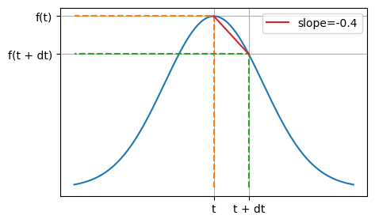

## Modified Newton's method

- Recall that $f'(x) = \lim_{\mathrm{d}x \to 0} \frac{f(x + \mathrm{d}x) - f(x)}{\mathrm{d}x}$.
- Hence we can choose a small value for $\mathrm{d}x$ (how small?) and approximate:

  $$ f'(x) \approx \frac{f(x + \mathrm{d}x) - f(x)}{\mathrm{d}x}. $$
- This modified-Newton method then becomes

  $$ x^{(i+1)} = x^{(i)} - \frac{\mathrm{d}x \times f(x^{(i)})}{f(x^{(i)} + \mathrm{d}x) - f(x^{(i)})}. $$

```python
def modified_newton(f, x0, dx, tol=1.0e-10):
    x = x0

    while abs(f(x)) > tol:
        df = (f(x + dx) - f(x)) / dx  # two extra evaluations of f
        # per iteration
        x = x - f(x) / df

    return x
```

```python
def modified_newton2(f, x0, dx, tol=1.0e-10):
    x = x0
    fx = f(x)

    while abs(fx) > tol:
        df = (f(x + dx) - fx) / dx  # one extra evaluations of f
        # per iteration
        x = x - fx / df
        fx = f(x)  # one original evaluation of f per iteration

    return x
```

## Graphical representation of modified Newton

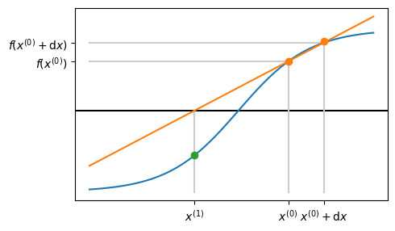

## How to choose $\mathrm{d}x$?

**Smaller** - more accurate approximation

**Large** - too small and we will have rounding problems (subtracting two similar numbers)

## Example

- When $f(x) = x^3$ then $f'(x) = 3 x^2$.
- Hence, at $x_0 = 1$, $f(x_0) = 1$ and $f'(x_0) = 3$.
- Consider what happens when we approximate this with python, using finite values for $\mathrm{d}x$.

Simple approximation of a derivative using floating point arithmetic

| dx | approx | abs error | rel error |
| --- | --- | --- | --- |
| 1.000000e-04 | 3.000300 | 3.000100e-04 | 1.000033e-04 |
| 1.000000e-06 | 3.000003 | 2.999798e-06 | 9.999326e-07 |
| 1.000000e-08 | 3.000000 | 3.972048e-09 | 1.324016e-09 |
| 1.000000e-10 | 3.000000 | 2.482211e-07 | 8.274037e-08 |
| 1.000000e-12 | 3.000267 | 2.667017e-04 | 8.890058e-05 |
| 1.000000e-14 | 2.997602 | 2.397834e-03 | 7.992778e-04 |
| 1.000000e-16 | 0.000000 | 3.000000e+00 | 1.000000e+00 |

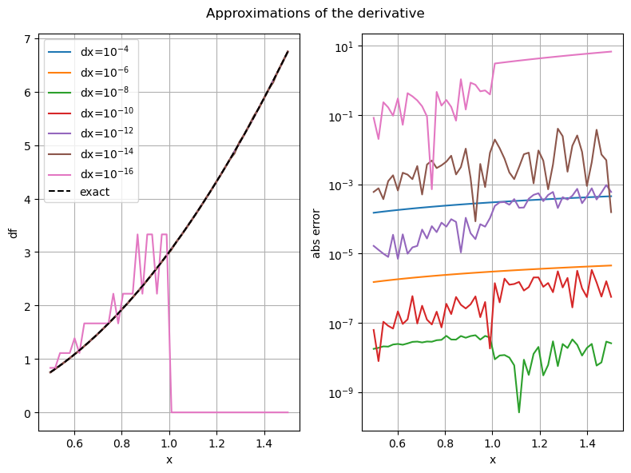

## A special choice!

- Recall the definition of machine precision/unit roundoff from Lecture 3.
- The modified Newton method uses $\mathrm{d}x = \sqrt{eps}$.

```python
eps = np.finfo(np.double).eps
dx = np.sqrt(eps)

print(f"{eps=} {dx=}")
```

```
eps=2.220446049250313e-16 dx=1.4901161193847656e-08
```

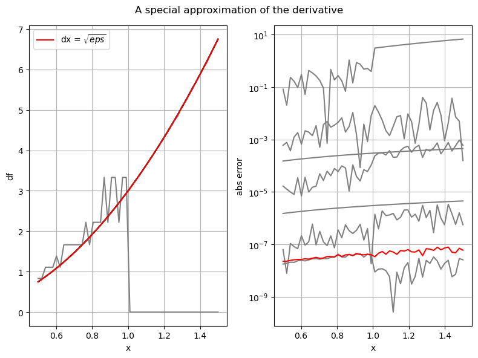

## Example

Recall the NACA0012 aerofoil example:

```python
def f_naca0012(x):
    t = 0.1

    yp = (
        -0.1015 * x**4 + 0.2843 * x**3 - 0.3516 * x**2 - 0.126 * x + 0.2969 * np.sqrt(x)
    )
    f = yp - 0.5 * t

    return f
```

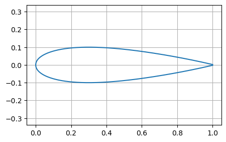

Starting from $x^{(0)} = 1$ with $TOL = 10^{-4}$, we get the root as $x^* \approx 0.765789$ after 2 iterations for the NACA0012 aerofoil example (Same as Newton!):

```python
modified_newton_with_table(f_naca0012, x0=1.0, tol=1.0e-4)
```

| iter | x | f(x) |
| --- | --- | --- |
| 0 | 1.000000 | -0.047900 |
| 1 | 0.795168 | -0.005392 |
| 2 | 0.765789 | -0.000096 |

Starting from $x^{(0)} = 0.1$ with $TOL = 10^{-4}$, we get the root as $x^* \approx 0.033863$ after 5 iterations for the second solution to the NACA0012 aerofoil example (Same as Newton!).

```python
modified_newton_with_table(f_naca0012, x0=0.1, tol=1.0e-4)
```

| iter | x | f(x) |
| --- | --- | --- |
| 0 | 0.100000 | 0.028046 |
| 1 | 0.000278 | -0.045086 |
| 2 | 0.005413 | -0.028849 |
| 3 | 0.020693 | -0.010046 |
| 4 | 0.031958 | -0.001300 |
| 5 | 0.033863 | -0.000024 |

# The secant method

> Can we use a similar derivative approximation but avoid the extra function evaluation?

Recall modified-Newton method:

$$ x^{(i+1)} = x^{(i)} - \frac{\mathrm{d}x \times f(x^{(i)})}{f(x^{(i)} + \mathrm{d}x) - f(x^{(i)})}. $$

Now with $\mathrm{d}x = x^{(i)} - x^{(i-1)}$ becomes

$$ x^{(i+1)} = x^{(i)} - \frac{(x^{(i)} - x^{(i-1)}) \times f(x^{(i)})}{f(x^{(i)}) - f(x^{(i-1)})}. $$

```python
def secant(f, x0, x1, tol=1.0e-10):
    # two initial function evaluations
    f0 = f(x0)
    f1 = f(x1)

    while abs(f1) > tol:
        # compute derivative approximation
        df = (f1 - f0) / (x1 - x0)
        # update x
        x2 = x1 - f1 / df

        # update other variables
        x0, f0 = x1, f1
        x1, f1 = x2, f(x2)  # one evaluation of f per iteration

    return x1
```

## A geometric interpretation

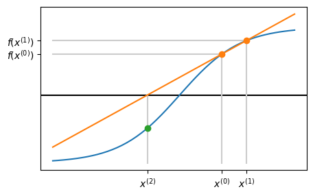

## Numerical examples

- The naca0012 example starting from 1 and 0.9 to a tolerance of $10^{-4}$ gives the solution as $x^* \approx 0.765264$ after 3 iterations (one more than Newton!)

```python
secant_with_table(f_naca0012, x0=1.0, x1=0.9, tol=1.0e-4)
```

| iter | x0 | f(x0) | x1 | f(x1) |
| --- | --- | --- | --- | --- |
| 0 | 1.000000 | -0.047900 | 0.900000 | -0.025871 |
| 1 | 0.900000 | -0.025871 | 0.782556 | -0.003095 |
| 2 | 0.782556 | -0.003095 | 0.766598 | -0.000239 |
| 3 | 0.766598 | -0.000239 | 0.765264 | -0.000003 |

Starting from $x^{(0)} = 0.0$ and $x^{(1)} = 0.1$ with $TOL = 10^{-4}$, we get the root as $x^* \approx 0.033870$ after 5 iterations for the second solution to the NACA0012 aerofoil example (Same as Newton!).

```python
secant_with_table(f_naca0012, x0=0.0, x1=0.1, tol=1.0e-4)
```

| iter | x0 | f(x0) | x1 | f(x1) |
| --- | --- | --- | --- | --- |
| 0 | 0.000000 | -0.050000 | 0.100000 | 0.028046 |
| 1 | 0.100000 | 0.028046 | 0.064065 | 0.015706 |
| 2 | 0.064065 | 0.015706 | 0.018327 | -0.012232 |
| 3 | 0.018327 | -0.012232 | 0.038352 | 0.002810 |
| 4 | 0.038352 | 0.002810 | 0.034611 | 0.000465 |
| 5 | 0.034611 | 0.000465 | 0.033870 | -0.000019 |

## Turning points?

```python
def f_turning(x):
    return (x - 1) ** 2


secant_with_table(f_turning, x0=4.0, x1=3.0, tol=1.0e-4)
```

| iter | x0 | f(x0) | x1 | f(x1) |
| --- | --- | --- | --- | --- |
| 0 | 4.000000 | 9.000000 | 3.000000 | 4.000000 |
| 1 | 3.000000 | 4.000000 | 2.200000 | 1.440000 |
| 2 | 2.200000 | 1.440000 | 1.750000 | 0.562500 |
| 3 | 1.750000 | 0.562500 | 1.461538 | 0.213018 |
| 4 | 1.461538 | 0.213018 | 1.285714 | 0.081633 |
| 5 | 1.285714 | 0.081633 | 1.176471 | 0.031142 |
| 6 | 1.176471 | 0.031142 | 1.109091 | 0.011901 |
| 7 | 1.109091 | 0.011901 | 1.067416 | 0.004545 |
| 8 | 1.067416 | 0.004545 | 1.041667 | 0.001736 |
| 9 | 1.041667 | 0.001736 | 1.025751 | 0.000663 |
| 10 | 1.025751 | 0.000663 | 1.015915 | 0.000253 |
| 11 | 1.015915 | 0.000253 | 1.009836 | 0.000097 |

## Other problems

Even more care is required to avoid divide by zero errors

```python
# equal function values at x0 and x1
secant(f_turning, x0=4.0, x1=-2.0, tol=1.0e-4)
```

```
---------------------------------------------------------------------------
ZeroDivisionError                         Traceback (most recent call last)
Cell In[23], line 2
      1 # equal function values at x0 and x1
----> 2 secant(f_turning, x0=4.0, x1=-2.0, tol=1.0e-4)

Cell In[17], line 10, in secant(f, x0, x1, tol)
      8 df = (f1 - f0) / (x1 - x0)
      9 # update x
---> 10 x2 = x1 - f1 / df
     12 # update other variables
     13 x0, f0 = x1, f1

ZeroDivisionError: float division by zero
```

```python
# too small tolerance means x0 = x1!
secant(f_turning, x0=4.0, x1=3.0, tol=1.0e-50)
```

```
---------------------------------------------------------------------------
ZeroDivisionError                         Traceback (most recent call last)
Cell In[24], line 2
      1 # too small tolerance means x0 = x1!
----> 2 secant(f_turning, x0=4.0, x1=3.0, tol=1.0e-50)

Cell In[17], line 8, in secant(f, x0, x1, tol)
      4 f1 = f(x1)
      6 while abs(f1) > tol:
      7     # compute derivative approximation
----> 8     df = (f1 - f0) / (x1 - x0)
      9     # update x
     10     x2 = x1 - f1 / df

ZeroDivisionError: float division by zero
```

## Exercise (hard!)

Find a periodic iteration for the secant method.

# Summary

|  | Bisection | Newton's method | Modified Newton | Secant |
| --- | --- | --- | --- | --- |
| Simple algorithm | yes | yes | yes | yes |
| Starting values | bracket | one | one | two |
| Iterations | lots | normally fewer | similar to Newton | similar to Newton |
| Function evals | one per iteration | `f` and `df` per iteration | two per iteration | one per iteration |
| Convergence | with good bracket | not always | not always | not always |
| Turing point roots | no | slower | slower | slower |
| Use of derivative | no | yes | no | no |

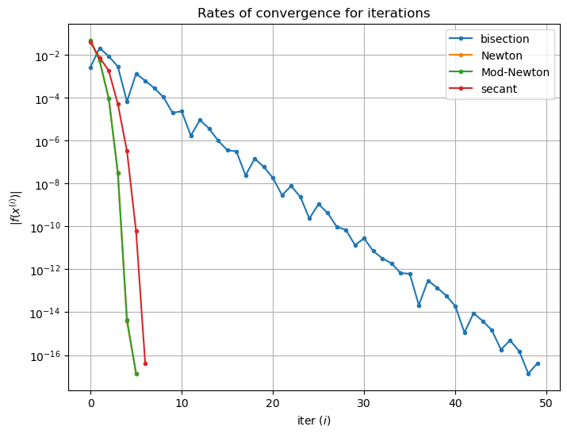

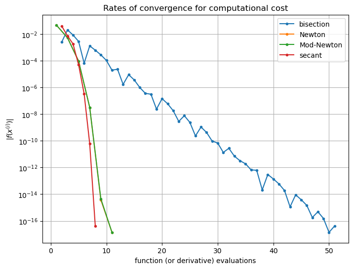